# Cost Complexity Pruning for Classification

## The Data

```
  Kyphosis Age Number Start
1   absent  71      3     5
2   absent 158      3    14
3  present 128      4     5
4   absent   2      5     1
5   absent   1      4    15
6   absent   1      2    16
```

From **rpart** package

`Kyphosis` – type of deformation `absent` or `present` after surgery

`Age` – in months

`Number` – the number of vertebrae involved

`Start` – the number of the first (topmost) vertebra operated on

## Growing the tree

```r
kmod <- rpart(Kyphosis ~ Age + Number + Start, data = kyphosis, cp = 0,
              minsplit = 2)
```

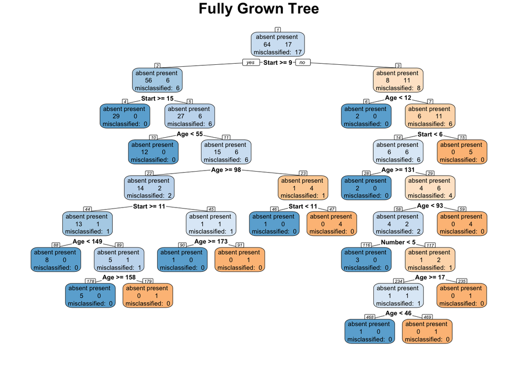

Figure 1: Colors based on class probabilities

## Cost complextiy pruning

First, some definitions:

- A *branch* includes an internal node and all of its descendants.
- *Pruning* a branch refers to removing all of the descendants of a node, i.e. collapsing them into the root node of the branch.
- A *subtree* refers to the original tree after pruning.

The pruning method used by **rpart** is called minimum cost complexity pruning and is described in Breiman et al. (1984). Of note: while the tree is grown using the Gini index to determine the next optimal split, pruning is based on *misclassification* rate.

The algorithm for pruning a classification tree begins with calculating the misclassification (or risk or cost or deviance) reduction *per split* for all internal nodes on the large tree. Considering the number of splits inherently incorporates a penality for the complexity of the tree.

For example, let’s consider the branch with root node 22. We have:

risk of branch: 0 (sum of misclassified in leaf nodes) risk of node: 2 (misclassified in node) number of splits in branch: 4 (nodes 22, 44, 89, 45)

Thus $g(t) = \frac{2 - 0}{4} = 0.5$

In simple language, it takes 4 splits to reduce the cost from 2 to 0, which averages to a 0.5 reduction per split.

The tree below displays $g(t)$ for all branches:

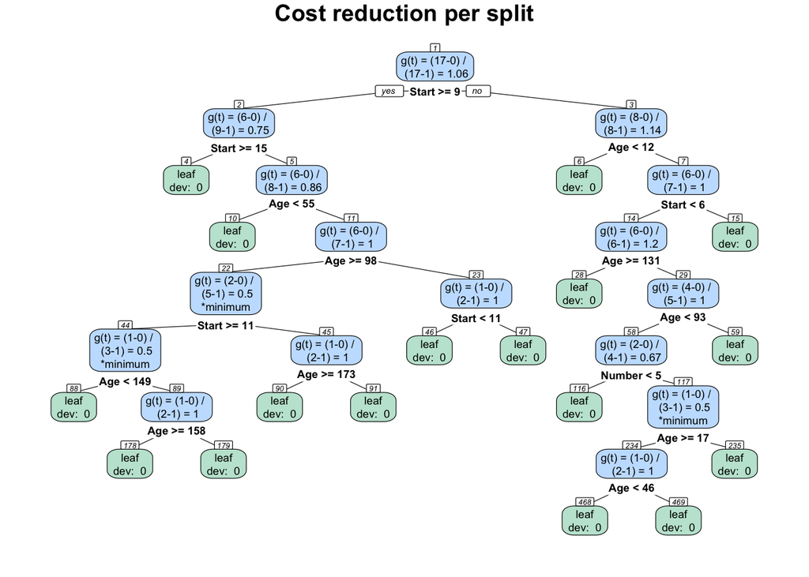

Figure 2

The weakest links have cost complexity of `0.5`.

In **rpart** these are scaled so that the root node has an error of 1, accomplished by dividing all values of `g(t)` by the deviance of the root node. In this case it is `17`, so the scaled complexity parameter (henceforth, cp) is `0.5/17 = 0.0294`. We will redraw the tree with the scaled values:

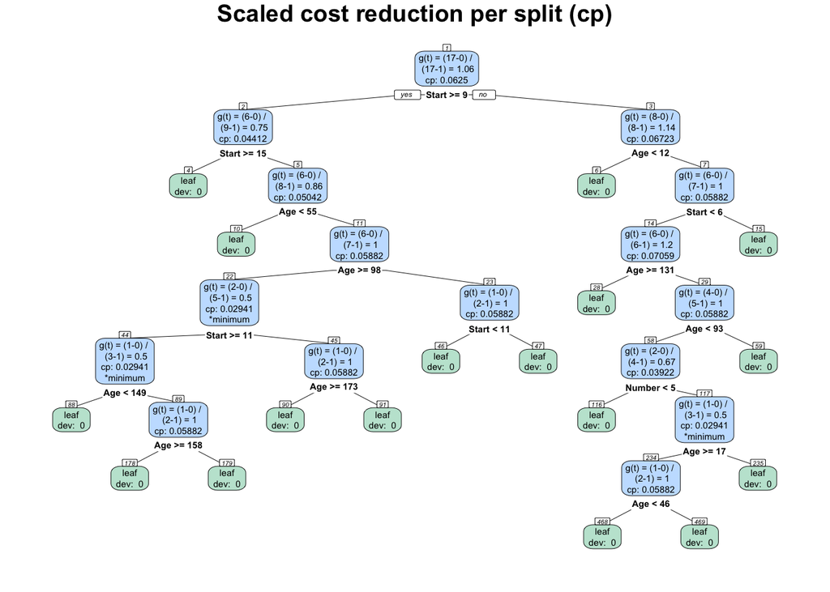

Figure 3: cp = g(t) / deviance of root node (=17)

To save space, henceforth we will only show the scaled values. In the tree below, we also indicate the minimum `cp` value by color (purple) and show the nodes which would be removed if we prune the tree at the nodes marked “*minimum”.

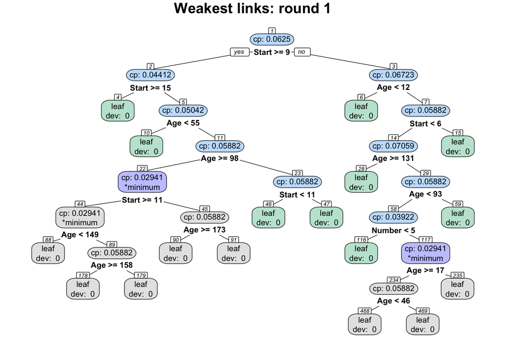

Figure 4: Nodes to be pruned in grey

Note that if we prune to `cp = .03` we will obtain the tree without the grey nodes:

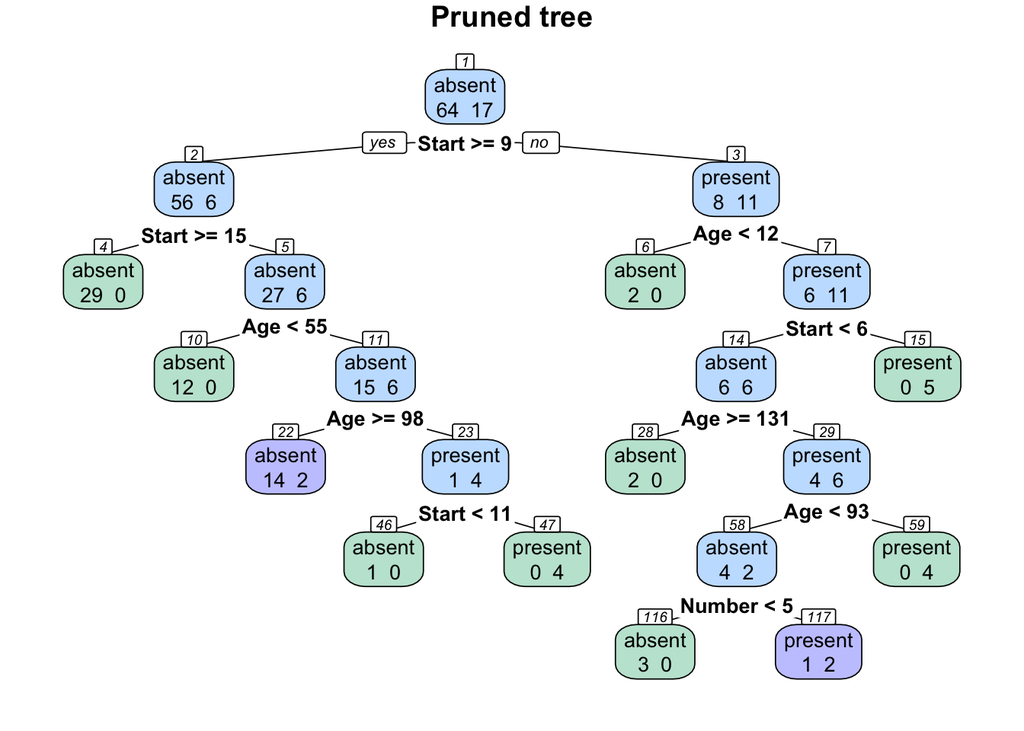

Figure 5: Internal nodes are shown in blue (10 in total)

```r
prp(prune(kmod, cp = .03), extra = 1, type = 2,
    box.col = colors, nn = TRUE)
mtext("Pruned tree", side = 3, line = 3, font = 2, cex = 1.2)
```

Note that before the pruning, our tree had 16 splits, and after the pruning 10 splits. Now let’s consider the end of the `cptable` returned by `rpart()`:

```
       CP nsplit rel error xerror   xstd
5 0.02941     10    0.1765  1.412 0.2417
6 0.00000     16    0.0000  1.412 0.2417
```

We see that a tree with `cp = 0` will have 16 splits and no error, evidenced by the 0 deviance in all nodes which we observed previously. For any `cp` value above 0.02941176 (and below the next threshold, to be determined) the tree will have 10 splits.

To determined the next threshold we need to recalculate $g(t)$ or `cp` (rememember `cp` = $g(t) / 17$, the deviance of the root node.) This is necessary because pruning the tree changes the cost reductions for the remaining nodes.

Now we need to continuing rececalculating $g(t)$ / `cp` for the pruned tree, find the minimum `cp` (weakest link), and the number of splits if we prune at the weakest links. The results are shown below:

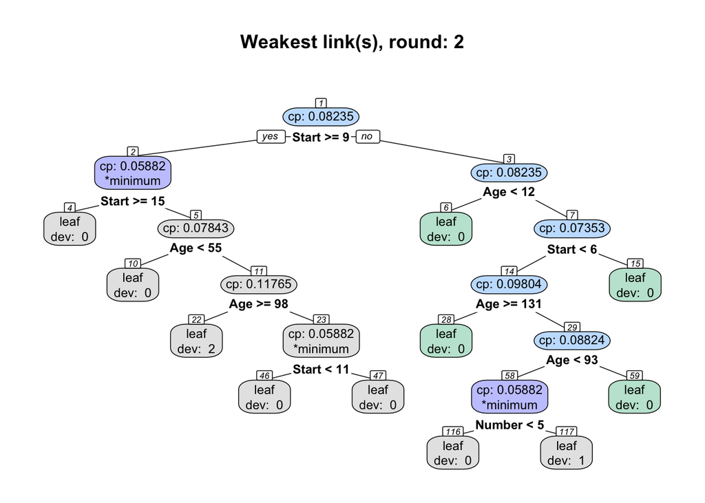

Minimum CP: 0.05882

Number of splits after pruning: 5

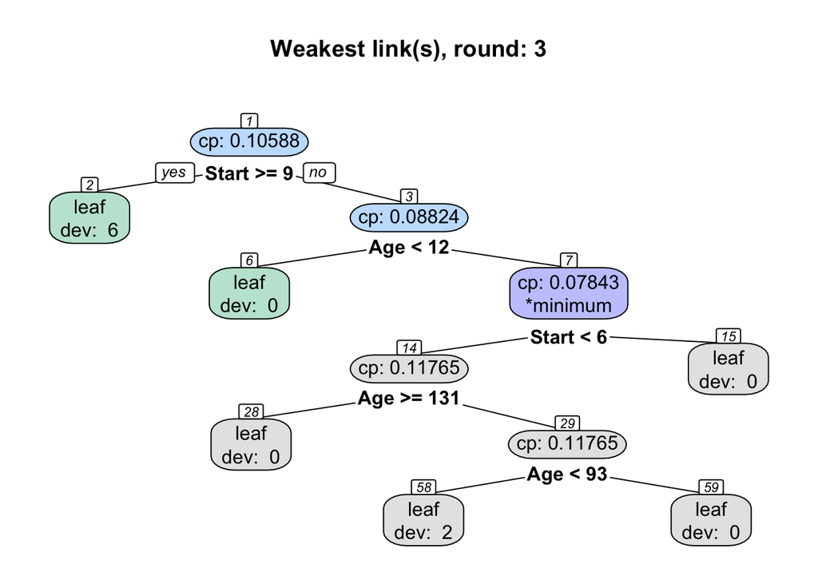

Minimum CP: 0.07843

Number of splits after pruning: 2

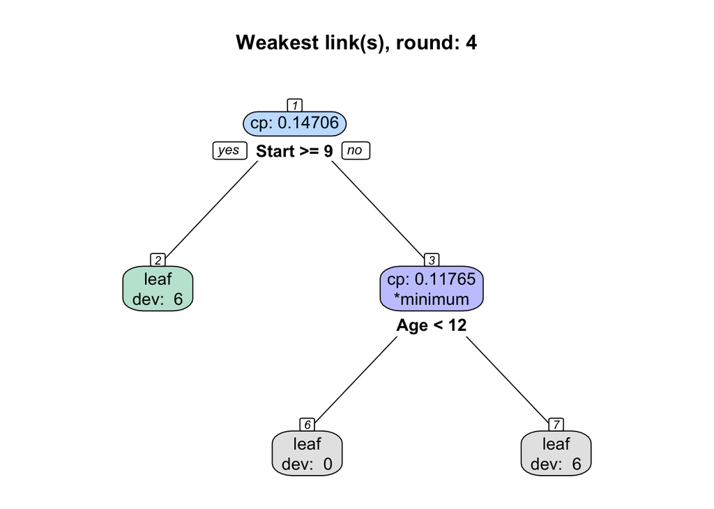

Minimum CP: 0.1176

Number of splits after pruning: 1

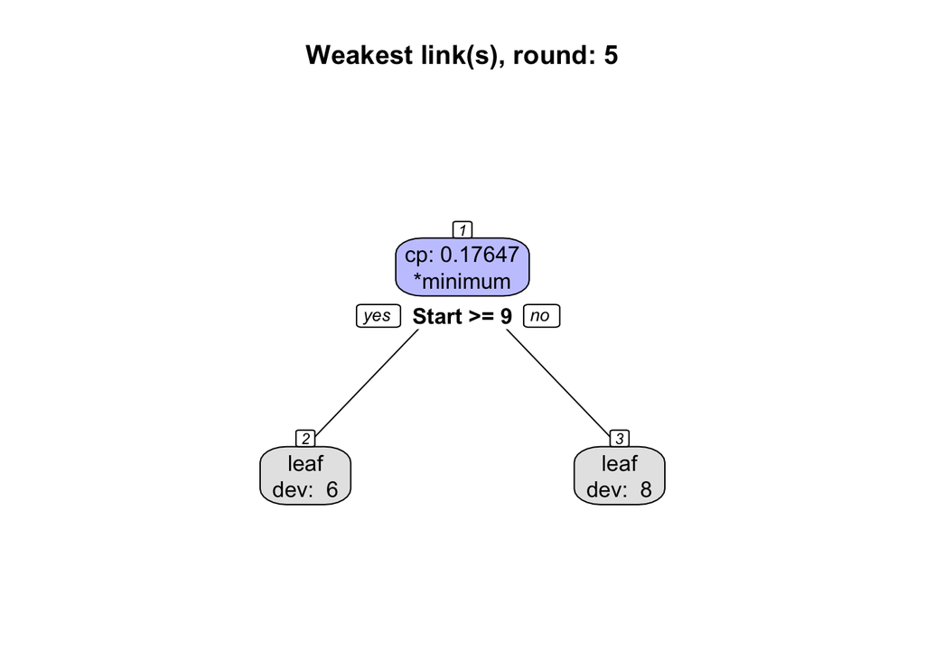

Minimum CP: 0.1765

Number of splits after pruning: 0

```
       CP nsplit rel error xerror   xstd
1 0.17647      0    1.0000  1.000 0.2156
2 0.11765      1    0.8235  1.294 0.2355
3 0.07843      2    0.7059  1.412 0.2417
4 0.05882      5    0.4706  1.412 0.2417
5 0.02941     10    0.1765  1.412 0.2417
6 0.00000     16    0.0000  1.412 0.2417
```